# Final Project

Creating groups from Data

Laudine Carbuccia

Sciences Po

# Motivations

## The broad picture

- Evidence that attending **high-quality early childcare** (e.g., daycare) is an effective lever to reduce inequalities during early childhood (Berger et al., 2020; Huizen & Plantenga, 2013; Schmutz, 2024): employment & child development.
- However, in most OECD countries there is an **early childcare enrollment gap** between households from low and high socioeconomic backgrounds (OECD, 2016).

[figure not shown]

## Understanding the SES-gap in early childcare enrollment

- *Supply-side factors*: **affordability, quality, and accessibility** of childcare services.
- *Demand-side factors*:
  1. Several factors could lead households to be **less willing to enroll** in these facilities.
  2. Several factors could prevent households to **apply** in these facilities.

## Research question

Who are the households who are willing to enroll and who are the ones who are not?

- 1849 questionnaires with households expecting a child in Paris region.
- **Intention** to enroll in early childcare facilities: binary variable with 80% of households willing to enroll.

```
  No  Yes
 358 1491
```

## Description of the variables

*Beliefs and norms*

- $Norms$: 2 variables 1) Share of people who actually enroll(ed) their child in early childcare, 2) Share of people who the participant think are opposed to the idea of enrolling their child in a childcare facility .
- $Impact$: Perceived impact of staying at home on 1) household income and on the mother’s 2) well-being, and 3) career.
- $Trust$: Trust in the each childcare facilities.
- Perceived $difficulty$ to access early childcare.
- Beliefs about the $benefits$ of early childcare for children development

**Knowledge**

- $Subsidies$: whether participants know that early childcare is heavily subsidized in France.
- $Types$ of early childcare known.

**Resources**

- Access to $informal$ *care*.
- Access to $information$.
- Access to $social$ *resources* to help with paperwork.
- Access to $computer$.

No SES variables were included in the clustering, but used later as covariates (`Education`, `BirthPlace`).

# Workflow

1. **Hierarchical** **clustering** using `agnes` and `complete` linkage
2. **Non**-**Hierarchical** clustering using `PAM`
3. **Fuzzy** clustering using `fanny`
4. **Latent Class Analysis**

[interactive chart not shown]

- Distance: `gower` because mixed data

# Results

**Hierarchical and Non-Hierarchical clustering**

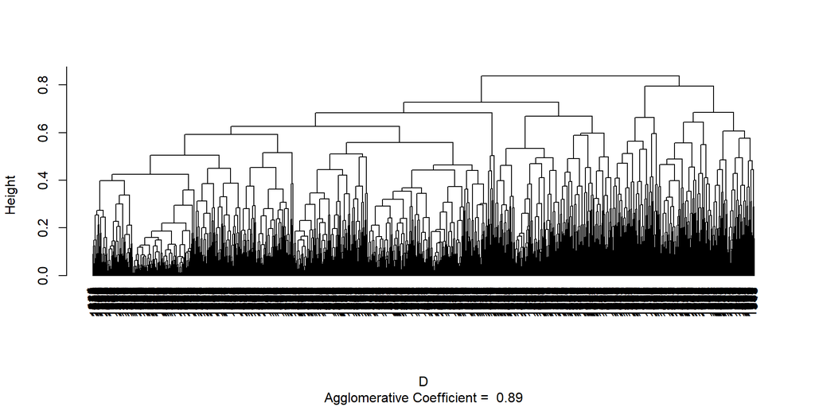

**Fuzzy clustering**

- 3 clusters solutions

**LCA**

- The 3 clusters solution has the lowest BIC

# Comparing solutions

## Non-Hierarchical clustering (PAM)

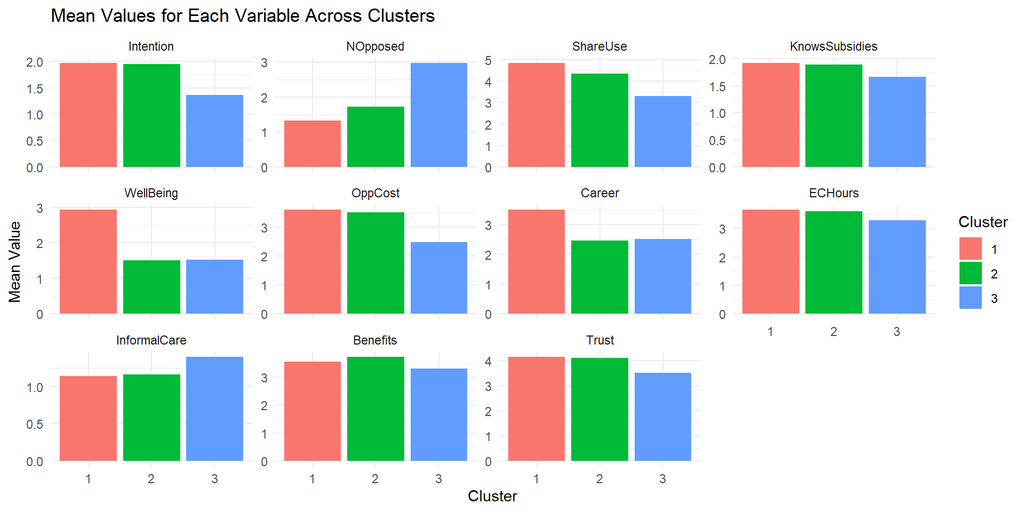

## Fuzzy clustering

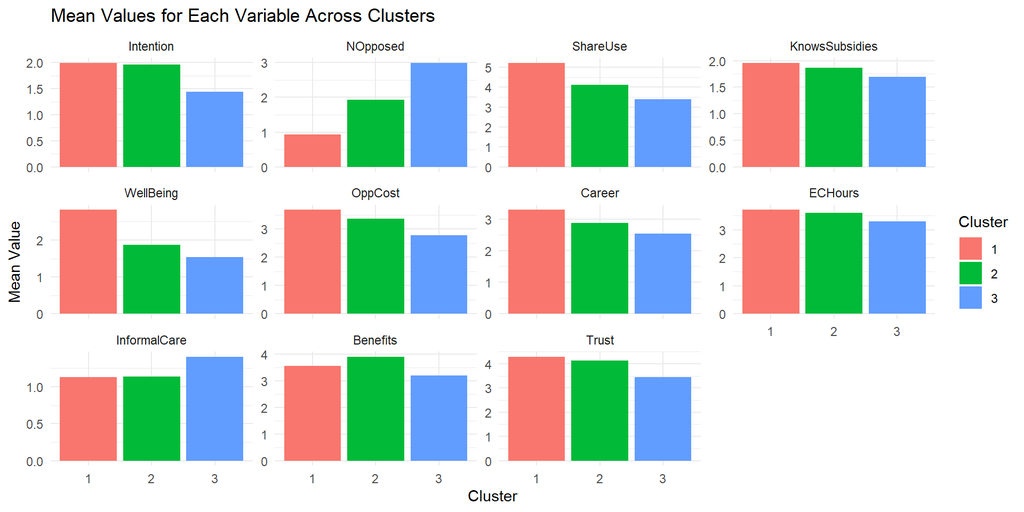

# Latent Class Analysis

## Plot Latent Classes

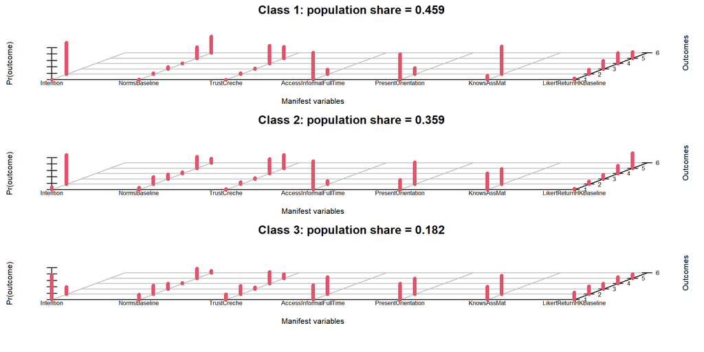

## Latent Classes description

```
Conditional item response (column) probabilities,
 by outcome variable, for each class (row)

$Intention
           Pr(1)  Pr(2)
class 1:  0.0075 0.9925
class 2:  0.0808 0.9192
class 3:  0.7617 0.2383

$NormsBaseline
           Pr(1)  Pr(2)  Pr(3)  Pr(4)  Pr(5)  Pr(6)
class 1:  0.0078 0.0423 0.0704 0.0142 0.3545 0.5109
class 2:  0.0674 0.2295 0.1433 0.0543 0.3641 0.1414
class 3:  0.1661 0.2743 0.1693 0.0246 0.3010 0.0647

$TrustCreche
           Pr(1)  Pr(2)  Pr(3)  Pr(4)  Pr(5)
class 1:  0.0028 0.0428 0.0270 0.5651 0.3624
class 2:  0.0191 0.0758 0.0308 0.4590 0.4153
class 3:  0.1761 0.2700 0.0510 0.3719 0.1311

$AccessInformalFullTime
           Pr(1)  Pr(2)
class 1:  0.8430 0.1570
class 2:  0.8892 0.1108
class 3:  0.4534 0.5466

$PresentOrientation
           Pr(1)  Pr(2)
class 1:  0.7948 0.2052
class 2:  0.3124 0.6876
class 3:  0.4995 0.5005

$KnowsAssMat
           Pr(1)  Pr(2)
class 1:  0.1215 0.8785
class 2:  0.5104 0.4896
class 3:  0.4110 0.5890

$LikertReturnHKBaseline
```

[output cut: 23 more lines]

```
            Coefficient  Std. error  t value  Pr(>|t|)
(Intercept)     1.00996     0.52639    1.919     0.055
Undergrad      -1.93523     0.29244   -6.618     0.000
Graduate       -4.19986     0.41666  -10.080     0.000
France         -0.45953     0.46956   -0.979     0.328
MENA            2.99884     0.54457    5.507     0.000
=========================================================
number of observations: 1344
number of estimated parameters: 61
residual degrees of freedom: 1283
maximum log-likelihood: -8147.413

AIC(3): 16416.83
BIC(3): 16734.23
X^2(3): 2823.104 (Chi-square goodness of fit)
```

# With grouping on the level of eduation

## Results

```
Call:
glca(formula = item(Intention, NormsBaseline, TrustCreche, AccessInformalFullTime,
    PresentOrientation, KnowsAssMat, LikertReturnHKBaseline) ~
    1, group = Educ3, data = work_df_cluster_LCA_small_group,
    nclass = 3, maxiter = 5000)

Manifest items : Intention NormsBaseline TrustCreche AccessInformalFullTime PresentOrientation KnowsAssMat LikertReturnHKBaseline
Grouping variable : Educ3

Categories for manifest items :
                                    Y = 1              Y = 2          Y = 3
Intention                              No                Yes
NormsBaseline                      Aucune       Une minorité  Moitié moitié
TrustCreche             Très en désaccord Assez en désaccord Je ne sais pas
AccessInformalFullTime                 No                Yes
PresentOrientation     NotPresentOriented    PresentOriented
KnowsAssMat                             1                  2
LikertReturnHKBaseline  Très en désaccord Assez en désaccord Je ne sais pas
                                Y = 4         Y = 5  Y = 6
Intention
NormsBaseline             Ne sait pas    La plupart Toutes
TrustCreche            Assez d’accord Très d’accord
AccessInformalFullTime
PresentOrientation
KnowsAssMat
LikertReturnHKBaseline Assez d’accord Très d’accord

Model : Multiple-group latent class analysis

Number of latent classes : 3
Number of groups : 3
Number of observations : 1344
Number of parameters : 57

log-likelihood : -8266.755
     G-squared : 2631.392
           AIC : 16647.51
           BIC : 16944.1

Marginal prevalences for latent classes :
```

[output cut: 30 more lines]

```
PresentOrientation
         Y = 1  Y = 2
Class 1 0.4868 0.5132
Class 2 0.7778 0.2222
Class 3 0.3885 0.6115
KnowsAssMat
         Y = 1  Y = 2
Class 1 0.4108 0.5892
Class 2 0.1336 0.8664
Class 3 0.4599 0.5401
LikertReturnHKBaseline
         Y = 1  Y = 2  Y = 3  Y = 4  Y = 5
Class 1 0.2702 0.2767 0.1917 0.1999 0.0614
Class 2 0.0415 0.1463 0.2906 0.3457 0.1759
Class 3 0.0495 0.1260 0.1086 0.2527 0.4632
```

## Additional explorations

|  | P(Apply to early childcare): Naïve | P(Apply to early childcare) | P(Use early childcare) |
| --- | --- | --- | --- |
| (Intercept) | 0.871*** [0.850, 0.892] | 0.928*** [0.900, 0.956] | 0.816*** [0.782, 0.850] |
|  | 0.011 (<0.001) | 0.014 (<0.001) | 0.017 (<0.001) |
| Intention = No | -0.588*** [-0.639, -0.537] |  |  |
|  | 0.026 (<0.001) |  |  |
| Clusters2 |  | -0.144*** [-0.186, -0.101] | -0.340*** [-0.390, -0.289] |
|  |  | 0.022 (<0.001) | 0.026 (<0.001) |
| Clusters3 |  | -0.613*** [-0.668, -0.559] | -0.665*** [-0.730, -0.601] |
|  |  | 0.028 (<0.001) | 0.033 (<0.001) |
| R2 | 0.277 | 0.268 | 0.252 |
| R2 Adj. | 0.277 | 0.267 | 0.251 |
| Num.Obs. | 1344 | 1344 | 1344 |
| Std.Errors | IID | IID | IID |

Coefficient, 95 % CI in brackets, standard errors, p-value or adjusted p-value in parenthesis

|  | P(Apply to early childcare): Naïve | P(Apply to early childcare) | P(Use early childcare) |
| --- | --- | --- | --- |
| (Intercept) | 0.883*** [0.847, 0.919] | 0.928*** [0.900, 0.956] | 0.816*** [0.782, 0.850] |
|  | 0.018 (<0.001) | 0.014 (<0.001) | 0.017 (<0.001) |
| Undergrad | -0.094*** [-0.149, -0.040] |  |  |
|  | 0.028 (<0.001) |  |  |
| HigerEducOrLess | -0.244*** [-0.295, -0.192] |  |  |
|  | 0.026 (<0.001) |  |  |
| Clusters2 |  | -0.144*** [-0.186, -0.101] | -0.340*** [-0.390, -0.289] |
|  |  | 0.022 (<0.001) | 0.026 (<0.001) |
| Clusters3 |  | -0.613*** [-0.668, -0.559] | -0.665*** [-0.730, -0.601] |
|  |  | 0.028 (<0.001) | 0.033 (<0.001) |
| R2 | 0.061 | 0.268 | 0.252 |
| R2 Adj. | 0.059 | 0.267 | 0.251 |
| Num.Obs. | 1344 | 1344 | 1344 |
| Std.Errors | IID | IID | IID |

Coefficient, 95 % CI in brackets, standard errors, p-value or adjusted p-value in parenthesis

# Discussion

- “I don’t know” were merged with “No” in the intention variable. Should they be distinguished?
- Use dimension reduction techniques or score for some groups of predictors (e.g. knowledge).
- Try LCA with a bigger number of variables to see whether the findings hold.
- (If running regressions like this really makes sense) Re run the analyses to predict one year later on the control group only.

## References

Berger, L., Solaz, A., & Panico, L. (2020, April). *The Impact of Center-Based Childcare Attendance on Early Child Development: Evidence from the French Elfe Cohort*. Submitted manuscript.

Huizen, V., & Plantenga, J. (2013). Universal Child Care and Children’s Outcomes: A Meta-Analysis of Evidence from Natural Experiments. U.S.E Discussion Paper Series.

OECD. (2016). Who uses childcare? Background brief on inequalities in the use of formal early childhood education and care (ECEC) among very young children. OECD.

Schmutz, R. (2024). Is universal early childhood education and care an equalizer? A systematic review and meta-analysis of evidence. *Research in Social Stratification and Mobility*, 89, 100859. DOI: 10.1016/j.rssm.2023.100859

Lugano Summer School 2024